# Practical Machine Learning - Course Project

Otavio Cals

# Introduction

In this project we explored and analyzed the Human Activity Recognition project data gathered by the Groupware@LES team about personal activity. Our goal will be to use data from accelerometers on the belt, forearm, arm, and dumbell of 6 participants to quantify how well they do their physical activities. They were asked to perform barbell lifts correctly and incorrectly in 5 different ways, those being:  
* A: exactly according to the specification  
* B: throwing the elbows to the front  
* C: lifting the dumbbell only halfway  
* D: lowering the dumbbell only halfway  
* E: throwing the hips to the front

We will use a train set and a cross-validation set to train two models and choose the best one to predict our test set.

# Loading the Data

First we load the date from the HAR project. The Training Data is avaiable here:  
https://d396qusza40orc.cloudfront.net/predmachlearn/pml-training.csv

The Testing Data is avaiable here:  
https://d396qusza40orc.cloudfront.net/predmachlearn/pml-testing.csv

```r
downcsv <- function(url, nas) {
    temp <- tempfile()
    download.file(url, temp, method = "curl")
    data <- read.csv(temp, na.strings = nas)
    unlink(temp)
    return(data)
}

trainurl <- "http://d396qusza40orc.cloudfront.net/predmachlearn/pml-training.csv"
train <- downcsv(trainurl, c("", "NA", "#DIV/0!"))

testurl <- "http://d396qusza40orc.cloudfront.net/predmachlearn/pml-testing.csv"
test <- downcsv(testurl, c("", "NA", "#DIV/0!"))
```

Now we analize the number of observations and features, and the distribution of the measured stances A,B,C,D,E:

```r
dim(train)
```

```
## [1] 19622   160
```

```r
table(train$classe)
```

```
##
##    A    B    C    D    E
## 5580 3797 3422 3216 3607
```

# Preprocessing

we start by loading the libraries that we will use in this analisys

```r
library(caret)
```

```r
library(rpart)
library(rpart.plot)
library(randomForest)
```

```r
set.seed(115687)

train<-train[,colSums(is.na(train)) == 0]
test <-test[,colSums(is.na(test)) == 0]

train <-train[,-c(1:7)]
test <-test[,-c(1:7)]

train_set <- createDataPartition(train$classe, p = 0.75, list = FALSE)
trainingset <- train[train_set, ]
validationset <- train[-train_set, ]
```

# Model Training

## Training: Decision Tree Model

We will train a Descision Tree Model using the rpart library and then plot it using rpart.plot

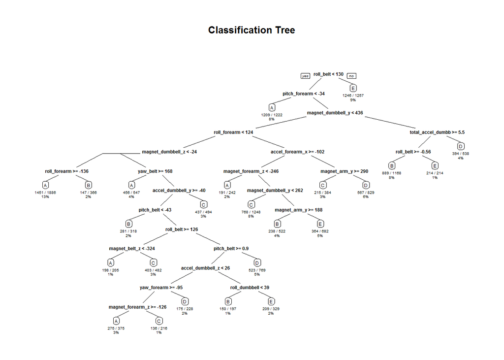

```r
model1 <- rpart(classe ~ ., data=trainingset, method="class")
prediction1 <- predict(model1, validationset, type = "class")

rpart.plot(model1, main="Classification Tree", extra=102, under=TRUE, faclen=0)
```

Now we test our model using by calculating it’s confusion matrix.

```r
confusionMatrix(prediction1, validationset$classe)
```

```
## Confusion Matrix and Statistics
##
##           Reference
## Prediction    A    B    C    D    E
##          A 1248  148   21   38    9
##          B   44  564   95   85   87
##          C   34  129  642   75   83
##          D   58   56   68  539   70
##          E   11   52   29   67  652
##
## Overall Statistics
##
##                Accuracy : 0.7433
##                  95% CI : (0.7308, 0.7555)
##     No Information Rate : 0.2845
##     P-Value [Acc > NIR] : < 2.2e-16
##
##                   Kappa : 0.6748
##  Mcnemar's Test P-Value : < 2.2e-16
##
## Statistics by Class:
##
##                      Class: A Class: B Class: C Class: D Class: E
## Sensitivity            0.8946   0.5943   0.7509   0.6704   0.7236
## Specificity            0.9384   0.9214   0.9207   0.9385   0.9603
## Pos Pred Value         0.8525   0.6446   0.6667   0.6814   0.8039
## Neg Pred Value         0.9573   0.9044   0.9460   0.9356   0.9392
## Prevalence             0.2845   0.1935   0.1743   0.1639   0.1837
## Detection Rate         0.2545   0.1150   0.1309   0.1099   0.1330
## Detection Prevalence   0.2985   0.1784   0.1964   0.1613   0.1654
## Balanced Accuracy      0.9165   0.7578   0.8358   0.8045   0.8420
```

## Training: Random Forest Model

Now we train a Random Forest Model and calculate it’s confusion matrix.

```r
model2 <- randomForest(classe ~. , data=trainingset, method="class")
prediction2 <- predict(model2, validationset, type = "class")

confusionMatrix(prediction2, validationset$classe)
```

```
## Confusion Matrix and Statistics
##
##           Reference
## Prediction    A    B    C    D    E
##          A 1395    9    0    0    0
##          B    0  940    8    0    0
##          C    0    0  845    9    0
##          D    0    0    2  794   10
##          E    0    0    0    1  891
##
## Overall Statistics
##
##                Accuracy : 0.992
##                  95% CI : (0.9891, 0.9943)
##     No Information Rate : 0.2845
##     P-Value [Acc > NIR] : < 2.2e-16
##
##                   Kappa : 0.9899
##  Mcnemar's Test P-Value : NA
##
## Statistics by Class:
##
##                      Class: A Class: B Class: C Class: D Class: E
## Sensitivity            1.0000   0.9905   0.9883   0.9876   0.9889
## Specificity            0.9974   0.9980   0.9978   0.9971   0.9998
## Pos Pred Value         0.9936   0.9916   0.9895   0.9851   0.9989
## Neg Pred Value         1.0000   0.9977   0.9975   0.9976   0.9975
## Prevalence             0.2845   0.1935   0.1743   0.1639   0.1837
## Detection Rate         0.2845   0.1917   0.1723   0.1619   0.1817
## Detection Prevalence   0.2863   0.1933   0.1741   0.1644   0.1819
## Balanced Accuracy      0.9987   0.9942   0.9930   0.9923   0.9943
```

## Picking a Model

We verify now that the Decision Tree Model presented a 0.7433 accuracy rate on the cross-validation set while the Random Tree Model presented a 0.992 accuracy rate on the cross-validation set. Therefore we will use the Random Forest Model to predict our test set. Since we have such a high accuracy rate, our out of sample error should be none or very close to none.

# Predicting

We now perform our prediction on the test set using the chosen model and conclude that the classes of each of the 20 individuals of the test set are:

```r
final_prediction <- predict(model2, test, type="class")
final_prediction
```

```
##  1  2  3  4  5  6  7  8  9 10 11 12 13 14 15 16 17 18 19 20
##  B  A  B  A  A  E  D  B  A  A  B  C  B  A  E  E  A  B  B  B
## Levels: A B C D E
```